# Multi-Lesion RECIST Progression and PFS/OS Modeling

Pharmacometrics-inspired modeling in oncology (part 3)

Juliette Bouli-Mengue

## 1. Motivation

Notebooks 1 and 2 modeled a single aggregate tumor size (SLD) per patient. In reality, RECIST 1.1 (Eisenhauer et al., 2009; doi:10.1016/j.ejca.2008.10.026) criteria are based on the **sum** of individually measured target lesions (up to 5 in total and up to 2 per organ), each of which may respond differently to treatment even within the same patient. This notebook implements the target-lesion component plus an assumed new-lesion process, and extends the framework by:

- simulating multiple individual lesions per patient,
- deriving total SLD as their sum,
- detecting disease progression using RECIST 1.1 rules (rather than treating progression as an abstract hazard, as in previous notebooks),
- constructing Progression-Free Survival (PFS) as a composite time-to-event endpoint (the earliest of RECIST progression or death),
- comparing PFS and OS on the same simulated patients.

```r
library(dplyr)
library(ggplot2)
library(survival)
library(survminer)

project_root <- Sys.getenv("TUMOR_PROJECT_ROOT", unset = "..")
source(file.path(project_root, "R", "config.R"))
source(file.path(project_root, "R", "recist.R"))
set_project_seed()
```

**Setup check.** Shared RECIST functions and the fixed seed ensure that lesion generation, progression detection, and endpoint construction are reproducible without copying business rules into the notebook.

## 2. Loading the simulated population

We reuse the simulated oncology population generated in notebook 1: each patient has individual tumor growth parameters (`g`, `d`) representing their overall disease trajectory. These patient-level parameters will serve as the basis for simulating several individual lesions per patient in Section 3.

```r
# Assumes patients_final.rds is saved in the same folder as this notebook
# (produced by notebook 1), a relative path, so the project stays portable across machines.
patients <- readRDS("patients_final.rds")

head(patients)
```

```
## # A tibble: 6 × 11
##   patient_id      g       d  SLD0      g_c       d_c linear_pred  hazard
##        <int>  <dbl>   <dbl> <dbl>    <dbl>     <dbl>       <dbl>   <dbl>
## 1          1 0.0397 0.00301  89.6  0.0175  -0.00885      -0.440  0.00966
## 2          2 0.0151 0.0122   46.2 -0.00707  0.000358      0.113  0.0168
## 3          3 0.0240 0.0202   61.0  0.00184  0.00833       0.139  0.0172
## 4          4 0.0274 0.0344   60.9  0.00530  0.0225        0.372  0.0217
## 5          5 0.0245 0.00438  50.4  0.00233 -0.00748      -0.185  0.0125
## 6          6 0.0190 0.00501  44.5 -0.00318 -0.00685      -0.0892 0.0137
## # ℹ 3 more variables: true_event_time <dbl>, os_time <dbl>, os_event <int>
```

**Input check.** The same 200-patient population from Notebook 01 is reused. Survival ground truth therefore stays fixed while the disease representation changes from one aggregate burden to multiple lesions.

## 3. Simulating multiple lesions per patient

RECIST-based tumor burden is the **sum** of several individually measured target lesions (up to 5 in clinical practice), each of which may respond differently to treatment even within the same patient. Rather than continuing to treat SLD as a single aggregate value per patient, we simulate 5 to 10 individual lesions per patient, each with its own growth (`g_lesion`) and regrowth (`d_lesion`) rate, and its own baseline size (`SLD0_lesion`). All derived from the patient-level parameters (`g`, `d`, `SLD0`) from notebook 1, with lesion-specific variation applied on top.

```r
n_lesions_min <- 5
n_lesions_max <- 10

lesions <- patients %>%
  rowwise() %>%
  do({
    pt <- .
    n_lesions <- sample(n_lesions_min:n_lesions_max, 1)

    tibble(
      patient_id = pt$patient_id,
      lesion_id = 1:n_lesions,
      g_lesion = pt$g * runif(n_lesions, 0.7, 1.3),
      d_lesion = pt$d * runif(n_lesions, 0.7, 1.3),
      SLD0_lesion = (pt$SLD0 / n_lesions) * runif(n_lesions, 0.7, 1.3)
    )
  }) %>%
  ungroup()

head(lesions, 15)
```

```
## # A tibble: 15 × 5
##    patient_id lesion_id g_lesion d_lesion SLD0_lesion
##         <int>     <int>    <dbl>    <dbl>       <dbl>
##  1          1         1   0.0501  0.00344       20.3
##  2          1         2   0.0346  0.00235       22.6
##  3          1         3   0.0476  0.00329       15.3
##  4          1         4   0.0431  0.00338       17.5
##  5          1         5   0.0401  0.00293       22.6
##  6          2         1   0.0116  0.0152         3.81
##  7          2         2   0.0149  0.0118         5.75
##  8          2         3   0.0156  0.0147         4.93
##  9          2         4   0.0187  0.0140         4.29
## 10          2         5   0.0118  0.0145         4.44
## 11          2         6   0.0195  0.0114         3.34
## 12          2         7   0.0191  0.0136         5.94
## 13          2         8   0.0113  0.00858        4.43
## 14          2         9   0.0152  0.0147         5.89
## 15          2        10   0.0141  0.00861        5.70
```

```r
cat("Number of lesions per patient,  summary:\n")
```

```
## Number of lesions per patient,  summary:
```

```r
summary(table(lesions$patient_id))
```

```
## Number of cases in table: 1525
## Number of factors: 1
```

```r
lesions %>%
  group_by(patient_id) %>%
  summarise(n_lesions = n()) %>%
  summarise(min_lesions = min(n_lesions), max_lesions = max(n_lesions), mean_lesions = mean(n_lesions))
```

```
## # A tibble: 1 × 3
##   min_lesions max_lesions mean_lesions
##         <int>       <int>        <dbl>
## 1           5          10         7.62
```

**Observation.** Each patient receives between five and ten lesions as specified. The lesion parameters remain anchored to patient-level dynamics, while bounded variation introduces within-patient heterogeneity without creating unrelated disease courses.

## 4. Simulating individual lesion trajectories and total tumor burden

Each lesion follows the same biexponential TGI equation used in notebook 1, but with its own lesion-specific parameters instead of the patient-level ones. We simulate scans every 6 weeks over 104 weeks, matching the follow-up duration used for the survival outcomes in notebook 1, then sum all lesions belonging to the same patient at each time point to obtain total SLD, exactly as RECIST defines it.

```r
assessment_times <- seq(0, 104, by = 6)

lesion_trajectories <- lesions %>%
  rowwise() %>%
  do({
    ls <- .
    tibble(
      patient_id = ls$patient_id,
      lesion_id = ls$lesion_id,
      time = assessment_times,
      diameter = ls$SLD0_lesion * (exp(-ls$g_lesion * assessment_times) + exp(ls$d_lesion * assessment_times) - 1)
    )
  }) %>%
  ungroup()

total_sld <- lesion_trajectories %>%
  group_by(patient_id, time) %>%
  summarise(SLD_total = sum(diameter), .groups = "drop")

head(total_sld, 12)
```

```
## # A tibble: 12 × 3
##    patient_id  time SLD_total
##         <int> <dbl>     <dbl>
##  1          1     0      98.3
##  2          1     6      78.0
##  3          1    12      62.7
##  4          1    18      51.4
##  5          1    24      43.1
##  6          1    30      37.2
##  7          1    36      33.0
##  8          1    42      30.3
##  9          1    48      28.6
## 10          1    54      27.9
## 11          1    60      27.8
## 12          1    66      28.2
```

At each scan, we compare the current total SLD to the **nadir**, the lowest SLD value observed for that patient up to and including that time point. Progression is declared the first time both RECIST conditions are met simultaneously: at least a 20% increase from nadir, and at least a 5mm absolute increase from nadir.

```r
recist_data <- detect_progression(total_sld, "SLD_total")

head(recist_data, 12)
```

```
## # A tibble: 12 × 7
##    patient_id  time SLD_total nadir relative_increase absolute_increase
##         <int> <dbl>     <dbl> <dbl>             <dbl>             <dbl>
##  1          1     0      98.3  98.3            0                  0
##  2          1     6      78.0  78.0            0                  0
##  3          1    12      62.7  62.7            0                  0
##  4          1    18      51.4  51.4            0                  0
##  5          1    24      43.1  43.1            0                  0
##  6          1    30      37.2  37.2            0                  0
##  7          1    36      33.0  33.0            0                  0
##  8          1    42      30.3  30.3            0                  0
##  9          1    48      28.6  28.6            0                  0
## 10          1    54      27.9  27.9            0                  0
## 11          1    60      27.8  27.8            0                  0
## 12          1    66      28.2  27.8            0.0156             0.432
## # ℹ 1 more variable: is_progression <lgl>
```

```r
recist_data %>% filter(patient_id == 4) %>% select(time, SLD_total, nadir, relative_increase, absolute_increase, is_progression)
```

```
## # A tibble: 18 × 6
##     time SLD_total nadir relative_increase absolute_increase is_progression
##    <dbl>     <dbl> <dbl>             <dbl>             <dbl> <lgl>
##  1     0      58.1  58.1            0                   0    FALSE
##  2     6      61.8  58.1            0.0645              3.75 FALSE
##  3    12      69.4  58.1            0.194              11.3  FALSE
##  4    18      81.1  58.1            0.396              23.0  TRUE
##  5    24      97.5  58.1            0.680              39.5  TRUE
##  6    30     119.   58.1            1.06               61.4  TRUE
##  7    36     148.   58.1            1.55               89.9  TRUE
##  8    42     184.   58.1            2.17              126.   TRUE
##  9    48     230.   58.1            2.95              171.   TRUE
## 10    54     286.   58.1            3.93              228.   TRUE
## 11    60     357.   58.1            5.14              299.   TRUE
## 12    66     444.   58.1            6.65              386.   TRUE
## 13    72     552.   58.1            8.51              494.   TRUE
## 14    78     686.   58.1           10.8               628.   TRUE
## 15    84     851.   58.1           13.7               793.   TRUE
## 16    90    1055.   58.1           17.2               997.   TRUE
## 17    96    1308.   58.1           21.5              1250.   TRUE
## 18   102    1621.   58.1           26.9              1562.   TRUE
```

**Quality check.** The patient example exposes every component of the rule—the running nadir, relative increase, absolute increase, and final flag—so the progression decision can be audited instead of treated as a black box.

## 6. Extracting time to RECIST progression

For each patient, we identify the first time point at which RECIST progression is detected. Patients who never meet the progression criteria within the follow-up window are treated as censored for progression at their last observed time point.

```r
target_progression_times <- extract_progression_times(recist_data)

# New lesions are an independent RECIST progression criterion. They appear as a Poisson
# process (assumed constant rate, ~30% of patients over 104 weeks) and are only observed
# at the next scheduled scan. The earliest of target-lesion progression and new-lesion
# detection defines progression.
new_lesion_rate <- -log(0.70) / 104
new_lesion_times <- simulate_new_lesion_times(
  target_progression_times$patient_id, new_lesion_rate, assessment_times
)
progression_times <- add_new_lesion_progression(target_progression_times, new_lesion_times)

head(progression_times, 10)
```

```
## # A tibble: 10 × 7
##    patient_id progression_time progression_event last_observed_time
##         <int>            <dbl>             <int>              <dbl>
##  1          1               90                 1                102
##  2          2               42                 1                102
##  3          3               24                 1                102
##  4          4               18                 1                102
##  5          5               96                 1                102
##  6          6               66                 1                102
##  7          7               66                 1                102
##  8          8               96                 1                102
##  9          9               60                 1                102
## 10         10               66                 1                102
## # ℹ 3 more variables: new_lesion_time <dbl>, target_progression_time <dbl>,
## #   progression_cause <chr>
```

```r
table(progression_times$progression_cause)
```

```
##
## new_lesion       none     target
##         25          7        168
```

```r
cat("Number of patients with RECIST progression detected:", sum(progression_times$progression_event), "out of", nrow(progression_times), "\n")
```

```
## Number of patients with RECIST progression detected: 193 out of 200
```

```r
progression_times %>% filter(progression_event == 0)
```

```
## # A tibble: 7 × 7
##   patient_id progression_time progression_event last_observed_time
##        <int>            <dbl>             <int>              <dbl>
## 1         64               NA                 0                102
## 2         69               NA                 0                102
## 3         89               NA                 0                102
## 4        100               NA                 0                102
## 5        119               NA                 0                102
## 6        137               NA                 0                102
## 7        182               NA                 0                102
## # ℹ 3 more variables: new_lesion_time <dbl>, target_progression_time <dbl>,
## #   progression_cause <chr>
```

**Observation.** The extraction produces one progression record per patient and keeps non-progressors as censored observations at their last scan. Patients without observed progression are therefore not silently discarded. The `progression_cause` column shows how many progressions come from target-lesion growth versus a new lesion. The new-lesion rate is an illustrative assumption, not an estimate from clinical data.

## 7. Constructing PFS as a composite endpoint

Progression-Free Survival (PFS) is a composite time-to-event endpoint: a patient experiences a PFS event at the earliest of RECIST progression or death, whichever occurs first. We combine the RECIST progression times from Section 6 with the OS data from notebook 1 to construct PFS.

```r
# Non-informative loss to follow-up (assumed rate 0.002/week, ~19% of patients over
# 104 weeks), applied identically to PFS and OS. It censors patients before their
# event, which is how real trials avoid a near-100% event rate.
dropout_rate <- 0.002
dropout_time <- setNames(rexp(nrow(patients), rate = dropout_rate), patients$patient_id)

pfs_data <- patients %>%
  select(patient_id, os_time, os_event) %>%
  left_join(progression_times, by = "patient_id") %>%
  mutate(
    progression_time_filled = if_else(progression_event == 1, progression_time, last_observed_time),
    pfs_time_true = pmin(progression_time_filled, os_time),
    pfs_event_true = as.integer(progression_event == 1 | os_event == 1),
    dropout = dropout_time[as.character(patient_id)],
    pfs_time = pmin(pfs_time_true, dropout),
    pfs_event = as.integer(pfs_event_true == 1 & pfs_time_true <= dropout),
    os_event = as.integer(os_event == 1 & os_time <= dropout),
    os_time = pmin(os_time, dropout)
  )

head(pfs_data, 10)
```

```
## # A tibble: 10 × 15
##    patient_id os_time os_event progression_time progression_event
##         <int>   <dbl>    <int>            <dbl>             <int>
##  1          1  104           0               90                 1
##  2          2   48.8         1               42                 1
##  3          3   39.3         1               24                 1
##  4          4   16.0         1               18                 1
##  5          5   57.0         1               96                 1
##  6          6   24.4         1               66                 1
##  7          7    3.65        1               66                 1
##  8          8   88.7         1               96                 1
##  9          9   73.8         1               60                 1
## 10         10    6.49        1               66                 1
## # ℹ 10 more variables: last_observed_time <dbl>, new_lesion_time <dbl>,
## #   target_progression_time <dbl>, progression_cause <chr>,
## #   progression_time_filled <dbl>, pfs_time_true <dbl>, pfs_event_true <int>,
## #   dropout <dbl>, pfs_time <dbl>, pfs_event <int>
```

**Endpoint decision.** PFS is the earliest of detected RECIST progression (target or new lesion) and death, censored at loss to follow-up. The component times and event indicators remain in the table, preserving traceability for every composite endpoint.

## 8. Comparing PFS and OS

As expected clinically, PFS events typically occur earlier than OS events, since disease progression is usually detected before death. We visualize both endpoints on the same population using Kaplan-Meier curves.

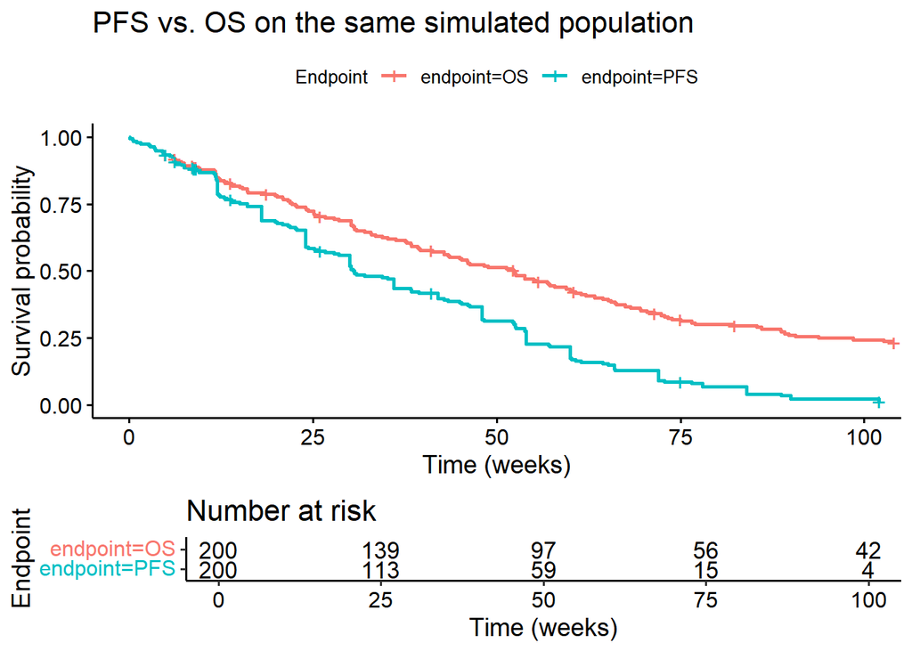

```r
comparison_data <- bind_rows(
  pfs_data %>% transmute(patient_id, time = pfs_time, event = pfs_event, endpoint = "PFS"),
  pfs_data %>% transmute(patient_id, time = os_time, event = os_event, endpoint = "OS")
)

km_comparison <- survfit(Surv(time, event) ~ endpoint, data = comparison_data)

ggsurvplot(km_comparison, data = comparison_data, risk.table = TRUE, pval = FALSE,
           xlab = "Time (weeks)", ylab = "Survival probability",
           title = "PFS vs. OS on the same simulated population",
           legend.title = "Endpoint")
```

```r
comparison_data %>%
  group_by(endpoint) %>%
  summarise(median_time = median(time), event_rate = mean(event))
```

```
## # A tibble: 2 × 3
##   endpoint median_time event_rate
##   <chr>          <dbl>      <dbl>
## 1 OS              46.2      0.725
## 2 PFS             30        0.945
```

**Result.** Median PFS is **30 weeks**, earlier than median OS at **46.2 weeks**. The PFS event rate is **94.5%**, compared with **72.5%** for OS. This ordering is coherent with the composite definition: progression can occur before death and therefore adds earlier events. Adding new-lesion progression and loss to follow-up moved these figures from the earlier target-lesion-only version (36 vs. 52.3 weeks, 98.5% vs. 77%), but the PFS event rate remains close to saturation. The cause is the notebook 1 regrowth model: the `exp(d*t)` term makes almost every simulated tumor progress within 104 weeks, and censoring can only remove a fraction of events. A lower event rate would require a different regrowth distribution in notebook 1, not another endpoint construction. This is therefore a stress-test scenario, not a realistic clinical-trial event rate, and it limits discrimination late in follow-up.

## 9. Conclusion, limitations, and decisions for Notebook 04

This notebook extends the tumor dynamics framework from notebooks 1 and 2 to a multi-lesion structure, closer to how RECIST is actually applied in clinical trials: total tumor burden as the sum of individually simulated lesions, progression detected via explicit RECIST 1.1 rules, and PFS constructed as a genuine composite endpoint rather than an independently simulated hazard.

**Decisions carried forward:**

1. Reuse the same RECIST functions for treated and untreated arms.
2. Evaluate progression independently in each counterfactual arm because each arm has its own nadir and tumor trajectory.
3. Combine this multi-lesion structure with the ADC mechanism and repeated dosing from Notebook 02.
4. Compare both PFS and OS, while expecting the modeled treatment effect to appear more directly in PFS.

**Limitations, stated explicitly:**

- Lesions are simulated as varying independently around the patient-level `g` and `d` from notebook 1, rather than being generated from a shared mechanistic process; this is a simplification of true inter-lesion heterogeneity (e.g., differential drug penetration or clonal resistance across metastatic sites).
- Scans continue at fixed 6-week intervals throughout the full follow-up window regardless of death, which is not clinically realistic (a deceased patient has no further scans); this does not bias `pfs_time` itself, since `pmin()` always resolves to the earlier of progression or death, but it is a modeling simplification worth noting.
- New lesion appearance is modeled as a homogeneous Poisson process with an assumed rate (~30% of patients over 104 weeks) and is not linked to tumor burden, drug exposure, or the patient’s growth parameters. Non-target and non-measurable disease are not modeled, so this remains a simplified implementation, not complete RECIST 1.1 adjudication.
- Loss to follow-up is assumed non-informative (constant rate, independent of disease course); informative dropout would bias PFS and OS.